# BMIN503/EPID600 Project COVID-19 and its impact in Biotechnology and Medical Device Industry

JIAYU LI

### Overview

This project will examine the effect of COVID-19 cases and resulting mortality rate with the performance of four different leading medical device during this Global Pandemic. The performance of each individual company will be measured based on their stock price due to limited access to confidential sales data. The companies selected are Medtronic, Boston Scientific, Stryker, and Zimmer Biomet. The stock price data for these four companies are obtained from Yahoo Finance and the COVID_19 cases in US are based on the data published by the Johns Hopkins University. Linear regression and random forest have been used in the project. The models are trained and tested based on the stock prices and Covid – 19 cases in 2020 and the prediction of the four companies’ performance are made using COVID_19 cases and mortality rate in 2021. Comparisons of the predicted stock prices of the four companies with the actual stock prices have been conducted. Based on the analysis, it is clear that except for the Zimmer Biomet stock with the 2020 mortality rate shows limited significance, the COVID-19 cases and mortality rate are significant to the stock prices of all four companies in 2020 and all models have low RMSE. However, the prediction of 2021 is not as accurate as the reality and may indicate that people and business are more adept or more confident towards the pandemic since the vaccination rate is ramping up so their performance or stock price are more reluctant to change along with the cases and death mortality change in 2021.

Dataset Used: 1.Stock Price: Yahoo Fiance (2020 - 2021) 2.COVID-19 cases Data: NYTimes and JHU dataset by states and counties(Kaggle) (2020 - 2021)

### Introduction

The world has changed a lot since the first COVID-19 cases has been reported in 2020. With the more and more cases had been reported, hospital beds quickly become a precious resource as more and more patients require hospitalization. Beds and ICU room quickly ran out in 2020 and governments had placed strict rules and regulations trying to slow movement of people to prevent the transmission of the virus. During this period, there’s a lot of rumors saying that companies in healthy sectors will record more sales and more revenue compared to pre-pandemic as other industries were experienced the toughest time they might have. However, this is incorrect for the medical device companies.

Unlike the pharmaceutical companies with possible vaccination product lines. Most of the product medical device companies have require in-patient treatment, such as cardiovascular intervention or knee replacement surgery. Patients need to physically present to the hospital to receive the procedure and hospital needs to have some spare beds or ICU rooms holding for possible medical emergency during the surgery. Also, global logistics disruption also affects the sales and manufacture of the medical device market hardly. Therefore, research of their performance with the cases and mortality rate change will be helpful for the medical device company to dynamically predict their sales and generate plan to prepare for the future. The four companies selected are among the top five in the industries and the one excluded from this study is Johnson & Johnson, which has a large pharmaceutical business sector, which means their vaccination products has the potential to significantly affect their performance, blocking the performance of their medical device sectors. Therefore, it has been excluded from the study. Linear regression models and random forest have been used in this study and direct comparison with the predict price and actual price in 2021 has been performed also.

### Methods

Data Loading: The COVID_19 Data and the stock price of the four companies in 2020 and 2021 are uploaded separatly

```r
US.covidcase=read.csv("Country.csv", header = TRUE)
temp_Data = US.covidcase
MDT = read.csv("MDT.csv",header = TRUE)
SYK = read.csv("SYK.csv",header = TRUE)
BSX = read.csv("BSX.csv",header = TRUE)
ZBH = read.csv("ZBH.csv",header = TRUE)
MRNA = read.csv("MRNA.csv",header = TRUE)
MDT_2021 = read.csv("MDT2021.csv",header = TRUE)
SYK_2021 = read.csv("SYK2021.csv",header = TRUE)
BSX_2021 = read.csv("BSX2021.csv",header = TRUE)
ZBH_2021 = read.csv("ZBH2021.csv",header = TRUE)
```

Data Cleaning: the data has been cleaned based on the data and prepared for regression later. The start data of the stock and the COVID_19 data file have a gap, so I matched it based on the date that have valid stock price data. Also, the COVID data has been divided in 2020 and 2021, which is used for training and validation of the model while the 2021 data will be used for prediciton.

```r
library(dplyr)
US_2021 = temp_Data[temp_Data$date >"2020-12-31",] %>%
  arrange(date) %>%
  group_by(date)
US_2021$increase.case = 0
US_2021$increase.death = 0

# calcualte the daily increase
for(i in 1:nrow(US_2021)){US_2021$increase.case[i] = US_2021$cases[i+1] - US_2021$cases[i]}
for(i in 1:nrow(US_2021)){US_2021$increase.death[i] = US_2021$deaths[i+1] - US_2021$deaths[i]}
# Data Cleaning
US_2021 = rename(US_2021,Case = increase.case,Death = increase.death, Date = date)
US_2021_Case = select(US_2021,Date,Case)
US_2021_Death = select(US_2021,Date,Death)

#calculate the daily increase
US.covidcase$cases=US.covidcase$cases/1000
US.covidcase = US.covidcase[US.covidcase$date<"2021-01-01",] %>%
  arrange(date) %>%
  group_by(date)
US.covidcase$increase.case=0
US.covidcase$increase.death=0
US.covidcase$average.case=0
US.covidcase$average.death=0
#calculate the 7 days average
for (i in 1:nrow(US.covidcase)) {US.covidcase$increase.case[i]=US.covidcase$cases[i+1]-US.covidcase$cases[i]}
for (i in 1:nrow(US.covidcase)) {US.covidcase$increase.death[i]=US.covidcase$deaths[i+1]-US.covidcase$deaths[i]}

for (i in 1:nrow(US.covidcase)) {US.covidcase$average.case[i]=mean(US.covidcase$increase.case[i:i+6])}
for (i in 341:346) {US.covidcase$average.case[i]=mean(US.covidcase$increase.case[341:345])}
for (i in 1:nrow(US.covidcase)) {US.covidcase$average.death[i]=mean(US.covidcase$increase.death[i:i+6])}
for (i in 341:346) {US.covidcase$average.death[i]=mean(US.covidcase$increase.death[341:345])}
#select valid covid data in 2020
US.covidcase
```

```
## # A tibble: 346 x 7
## # Groups:   date [346]
##    date       cases deaths increase.case increase.death average.case average.death
##    <chr>      <dbl>  <int>         <dbl>          <dbl>        <dbl>         <dbl>
##  1 2020-01-21 0.001      0         0                  0      0                   0
##  2 2020-01-22 0.001      0         0                  0      0                   0
##  3 2020-01-23 0.001      0         0.001              0      0.001               0
##  4 2020-01-24 0.002      0         0.001              0      0.001               0
##  5 2020-01-25 0.003      0         0.002              0      0.001               0
##  6 2020-01-26 0.005      0         0                  0      0.003               0
##  7 2020-01-27 0.005      0         0                  0      0                   0
##  8 2020-01-28 0.005      0         0                  0      0                   0
##  9 2020-01-29 0.005      0         0.001              0      0.00100             0
## 10 2020-01-30 0.006      0         0.001              0      0                   0
## # ... with 336 more rows
```

```r
US.covidcase = US.covidcase[US.covidcase$date<"2020-12-31",]
```

The Stock data for 2020 and 2021 have been uploaded here and formalized to the same standard in order to future training, testing, and prediction.

```r
#2020 and 2021 Stock price loaded and formalized into same format
#Only the close price of the stock will be selected in this analysis.

#Medtronic
MDT$Date=as.Date(MDT$Date, format = "%m/%d/%y")
MDT_2021$Date = as.character.Date(MDT_2021$Date)
MDT_2021$Date=as.Date(MDT_2021$Date)
MDT_2021 = select(MDT_2021,Date, Close)

#Stryker
SYK$Date=as.Date(SYK$Date, format = "%m/%d/%y")
SYK_2021$Date = as.character.Date(SYK_2021$Date)
SYK_2021$Date=as.Date(SYK_2021$Date)
SYK_2021 = select(SYK_2021,Date, Close)

#Boston Scientific
BSX$Date=as.character.Date(BSX$Date)
BSX$Date=as.Date(BSX$Date)
BSX_2021$Date = as.character.Date(BSX_2021$Date)
BSX_2021$Date=as.Date(BSX_2021$Date)
BSX_2021 = select(BSX_2021,Date, Close)

#Zimmer Biomet
ZBH$Date=as.character.Date(ZBH$Date)
ZBH$Date=as.Date(ZBH$Date)
ZBH_2021$Date = as.character.Date(ZBH_2021$Date)
ZBH_2021$Date=as.Date(ZBH_2021$Date)
ZBH_2021 = select(ZBH_2021,Date, Close)

#Moderna
## the stock price of Moderna has also been uploaded to compare with stock price change for medical device company
MRNA$Date=as.character.Date(MRNA$Date)
MRNA$Date=as.Date(MRNA$Date)
```

The date of the stock market are matched with the date in the covid case and death increase dataset and are merged togther for future regression purpose.

```r
##select the case and death increase data for 2020
case_2020 = select(US.covidcase,date,increase.case)
case_2020$increase.case = case_2020$increase.case*1000
case_2020 = rename(case_2020, Date = date,Case = increase.case)
death_2020 = select(US.covidcase,date,increase.death)
death_2020 = rename(death_2020,Date = date,Death = increase.death)

#Medtronic 2020 stock price dateset with covid case and death data
MDT_new = MDT[MDT$Date > "2020-01-20",]
MDT_new$Date = as.character(MDT_new$Date)
MDT_2020 = merge(case_2020,MDT_new, by ="Date")
MDT_2020 = merge(death_2020,MDT_2020, by = "Date")
MDT_2020 = select(MDT_2020,Date,Close,Case,Death)

#Stryker 2020 stock price dataset with covid case and death data
SYK_new = SYK[SYK$Date > "2020-01-20",]
SYK_new$Date = as.character(SYK_new$Date)
SYK_2020 = merge(case_2020,SYK_new, by ="Date")
SYK_2020 = merge(death_2020,SYK_2020, by = "Date")
SYK_2020 = select(SYK_2020,Date, Close,Case,Death)

#Boston Scientific 2020 stock price with covid case and death data
BSX_new = BSX[BSX$Date > "2020-01-20",]
BSX_new$Date = as.character(BSX_new$Date)
BSX_2020 = merge(case_2020,BSX_new, by ="Date")
BSX_2020 = merge(death_2020,BSX_2020, by = "Date")
BSX_2020 = select(BSX_2020,Date,Close,Case,Death)

#Zimmer Biomet 2020 stock price with covid case and death data
ZBH_new = ZBH[ZBH$Date > "2020-1-20", ]
ZBH_new$Date = as.character(ZBH_new$Date)
ZBH_2020 = merge(case_2020,ZBH_new, by ="Date")
ZBH_2020 = merge(death_2020,ZBH_2020, by = "Date")
ZBH_2020 = select(ZBH_2020,Date, Close,Case,Death)

#Moderna 2020 stock price with covid case and death data
MRNA_new = MRNA[MRNA$Date > "2020-1-20",]
MRNA_new$Date = as.character(MRNA_new$Date)
MRNA_2020 = merge(case_2020,MRNA_new, by ="Date")
MRNA_2020 = merge(death_2020,MRNA_2020, by = "Date")
MRNA_2020 = select(MRNA_2020,Date, Close,Case,Death)
```

###Data Visualization The data will be visualized in this section to get a general view of the data and the corresponding trend in 2020 and 2021 and make general assumption based on the results to the the distribution

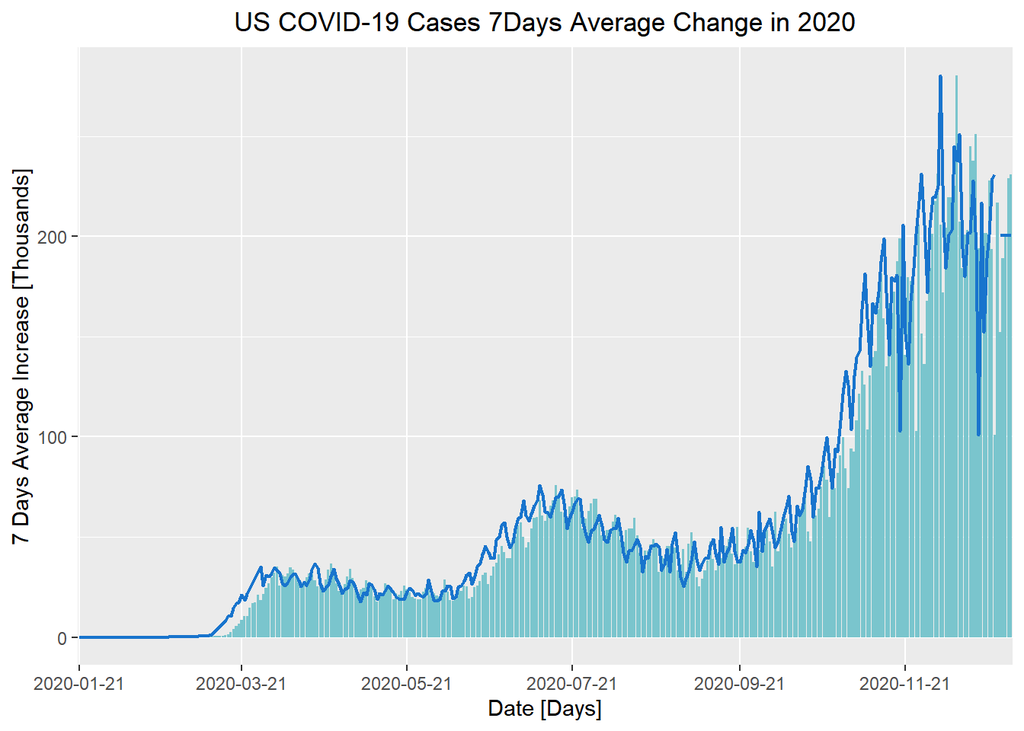

```r
#general distribution of the covid daily increase and 7 days average increase in 2020
ggplot(aes(US.covidcase$date,US.covidcase$increase.case,group=1),data=US.covidcase)+
  geom_bar(stat="identity",fill="cadetblue3")+
  scale_x_discrete(name="Date [Days]",breaks=c("2020-01-21","2020-03-21","2020-05-21","2020-07-21","2020-09-21","2020-11-21"))+
  geom_line(data=US.covidcase,aes(x=date,y=average.case),col="dodgerblue3",size=0.8)+ggtitle("US COVID-19 Cases 7Days Average Change in 2020") + ylab("7 Days Average Increase [Thousands]")+ xlab("Time [Days]")+ theme(plot.title = element_text(hjust = 0.5))
```

From the plot, we can clear see three peaks occured in March 2020, July 2020 and Novemeber 2020. The first two peaks has the daily increase not different too much between each other while the 3rd peak is significantly higher than the earlier two, which corresponding with the timeline of the outbreak of more contagious variant worldwide while the lockdown has been gradudatlly removed in this period.

[figure not shown]

```r
#general distribution of the Covid daily death increase and 7 days average increase in 2020
ggplot(aes(US.covidcase$date,US.covidcase$increase.death,group=1),data=US.covidcase)+
  geom_bar(stat="identity",fill="cadetblue3")+
  scale_x_discrete(name="Date [Days]",breaks=c("2020-01-21","2020-03-21","2020-05-21","2020-07-21","2020-09-21","2020-11-21"))+
  geom_line(data=US.covidcase,aes(x=date,y=average.death),col="dodgerblue3",size=0.8)+ggtitle("US COVID-19 Death 7Days Average Change in 2020") + ylab("7 Days Average Increase [Thousands]")+ xlab("Time [Days]")+ theme(plot.title = element_text(hjust = 0.5))
```

Unlinke the case increase, two peaks can be see clearly occured in April and in Novemeber, which make sense as the first wave is directly followed the first outbreak and the declared of pandemic by the WHO while the second peak coressponding with the contagious variable tramission worldwide.

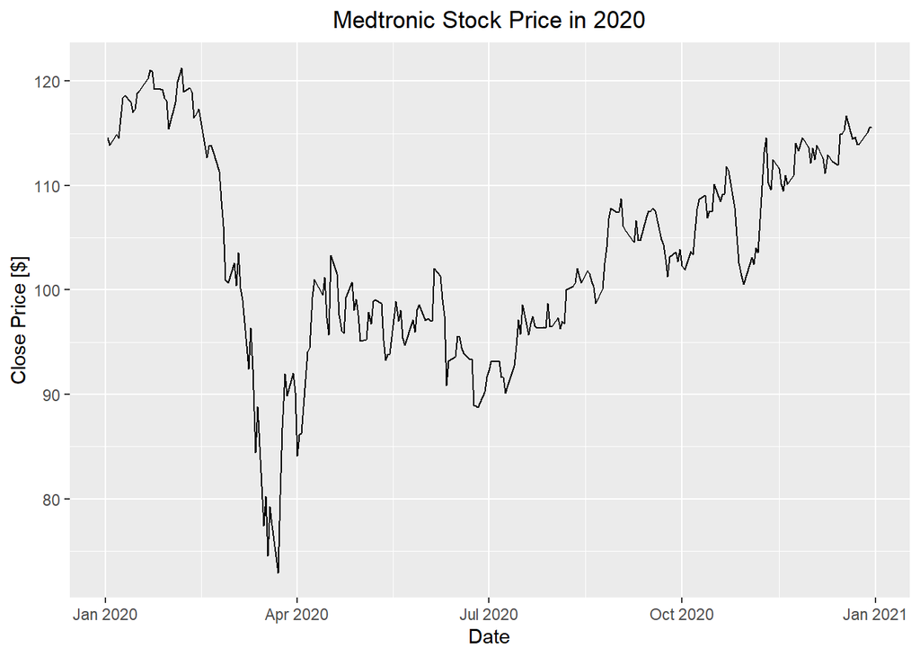

```r
ggplot(aes(Date,Close,group=1),data=MDT)+
   geom_line()+ggtitle("Medtronic Stock Price in 2020") + theme(plot.title = element_text(hjust = 0.5)) + ylab("Close Price [$]")
```

The stock price change of the Medtronic shows a large dip at the beginning of the pandemic when people are panic and have huge negative perspective for the market and the company, indicate a low expectation on the companies performance.A second dip also corresponding with the second small peak occurred in July and then after that, as the lock down have been gradually removed, the market started to increase, may have the potential to indicate that the investors are more confident about their performance and sale, and more patients are back to the hospital to get the procedure.

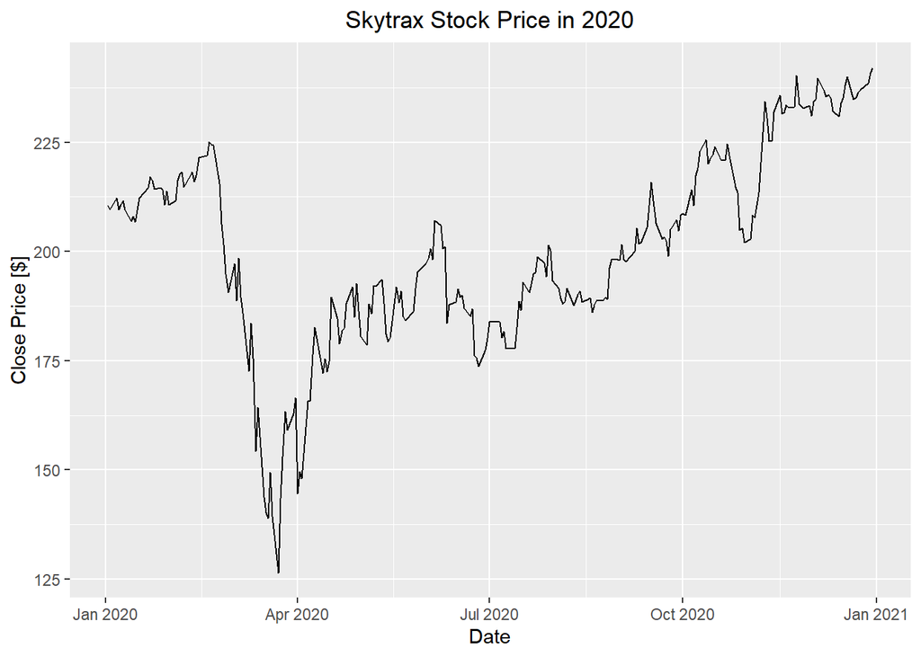

```r
ggplot(aes(Date,Close,group=1),data= SYK)+
   geom_line()+ggtitle("Skytrax Stock Price in 2020") + theme(plot.title = element_text(hjust = 0.5)) + ylab("Close Price [$]")
```

Similar trend can also been seen in Skytrax

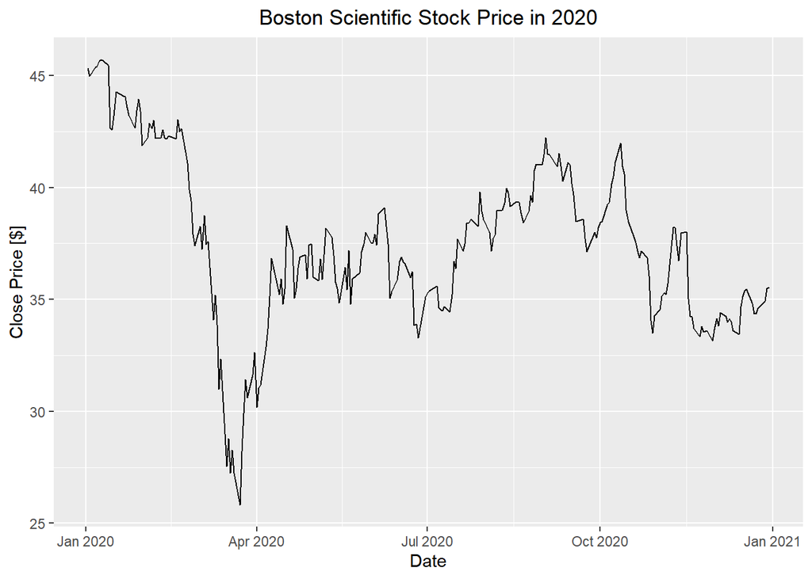

```r
ggplot(aes(Date,Close,group=1),data=BSX)+
   geom_line()+ggtitle("Boston Scientific Stock Price in 2020") + theme(plot.title = element_text(hjust = 0.5)) + ylab("Close Price [$]")
```

Unlike the other two, Boston scientific stock didn’t experienced contant increase in Q4 2020 and it starts to dip. This may indicate a posibility that most of the product or the procedure using Boston Scientific products may require inpatient care while the hosptial bed shortage became worse due to the 3rd outbreak. It may also indicate some decision or movement that Boston Scientific made in Q4 may not be appreciated by the investors and the market.

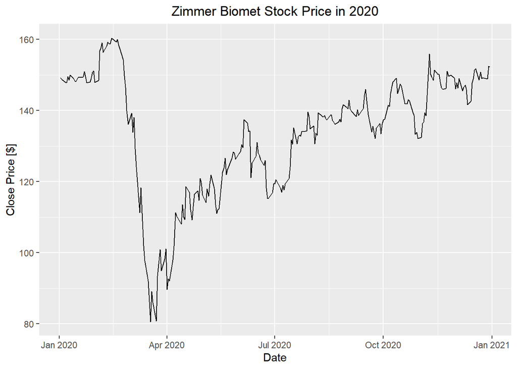

```r
ggplot(aes(Date,Close,group=1),data=ZBH)+
   geom_line()+ggtitle("Zimmer Biomet Stock Price in 2020") + theme(plot.title = element_text(hjust = 0.5)) + ylab("Close Price [$]")
```

Zimmer Biomet has similar trend with Medtronic and Stryker

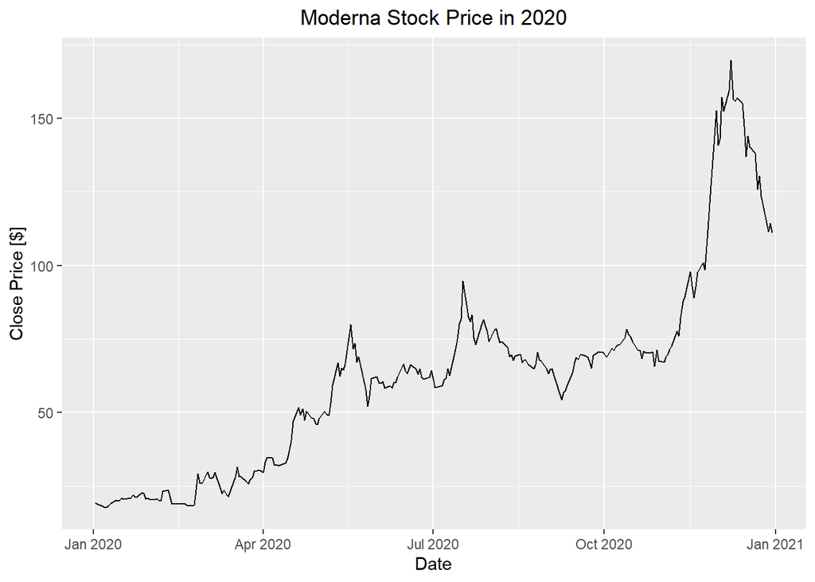

```r
ggplot(aes(Date,Close,group=1),data=MRNA)+ geom_line() +ggtitle("Moderna Stock Price in 2020") + theme(plot.title = element_text(hjust = 0.5)) + ylab("Close Price [$]")
```

```r
mrna_test_case = lm(MRNA_2020$Close ~ MRNA_2020$Case)
summary(mrna_test_case)
```

```
##
## Call:
## lm(formula = MRNA_2020$Close ~ MRNA_2020$Case)
##
## Residuals:
##     Min      1Q  Median      3Q     Max
## -35.751 -14.166   3.331  11.775  39.992
##
## Coefficients:
##                 Estimate Std. Error t value Pr(>|t|)
## (Intercept)    3.689e+01  1.315e+00   28.06   <2e-16 ***
## MRNA_2020$Case 4.608e-04  1.507e-05   30.58   <2e-16 ***
## ---
## Signif. codes:  0 '***' 0.001 '**' 0.01 '*' 0.05 '.' 0.1 ' ' 1
##
## Residual standard error: 14.82 on 238 degrees of freedom
## Multiple R-squared:  0.7971, Adjusted R-squared:  0.7963
## F-statistic:   935 on 1 and 238 DF,  p-value: < 2.2e-16
```

```r
mrna_test_death = lm(MRNA_2020$Close ~ MRNA_2020$Death)
summary(mrna_test_death)
```

```
##
## Call:
## lm(formula = MRNA_2020$Close ~ MRNA_2020$Death)
##
## Residuals:
##     Min      1Q  Median      3Q     Max
## -72.188 -12.642   3.409  12.404  63.678
##
## Coefficients:
##                 Estimate Std. Error t value Pr(>|t|)
## (Intercept)     33.94208    2.53880   13.37   <2e-16 ***
## MRNA_2020$Death  0.02630    0.00175   15.03   <2e-16 ***
## ---
## Signif. codes:  0 '***' 0.001 '**' 0.01 '*' 0.05 '.' 0.1 ' ' 1
##
## Residual standard error: 23.56 on 238 degrees of freedom
## Multiple R-squared:  0.4868, Adjusted R-squared:  0.4847
## F-statistic: 225.8 on 1 and 238 DF,  p-value: < 2.2e-16
```

Regression:Linear and random frost are performed here to determine the relationship between the covid 19 cases, covid 19 death rate increase, and the stock price for the four companies listed above. seed 103111 has been used here to randomized and divided the sample with 7:3 ratio in training and testing.

Linear Model

```r
set.seed(103111)
split = sample(1:240,0.7*240)
MDT_test_c = lm(MDT_2020$Close ~ MDT_2020$Case)
summary(MDT_test_c)
```

```
##
## Call:
## lm(formula = MDT_2020$Close ~ MDT_2020$Case)
##
## Residuals:
##      Min       1Q   Median       3Q      Max
## -26.6633  -5.3665  -0.2286   4.2743  22.3242
##
## Coefficients:
##                Estimate Std. Error t value Pr(>|t|)
## (Intercept)   9.898e+01  7.902e-01  125.25  < 2e-16 ***
## MDT_2020$Case 5.823e-05  9.056e-06    6.43 6.93e-10 ***
## ---
## Signif. codes:  0 '***' 0.001 '**' 0.01 '*' 0.05 '.' 0.1 ' ' 1
##
## Residual standard error: 8.903 on 238 degrees of freedom
## Multiple R-squared:  0.148,  Adjusted R-squared:  0.1444
## F-statistic: 41.34 on 1 and 238 DF,  p-value: 6.93e-10
```

```r
confint(MDT_test_c)
```

```
##                      2.5 %       97.5 %
## (Intercept)   9.741914e+01 1.005326e+02
## MDT_2020$Case 4.038614e-05 7.606511e-05
```

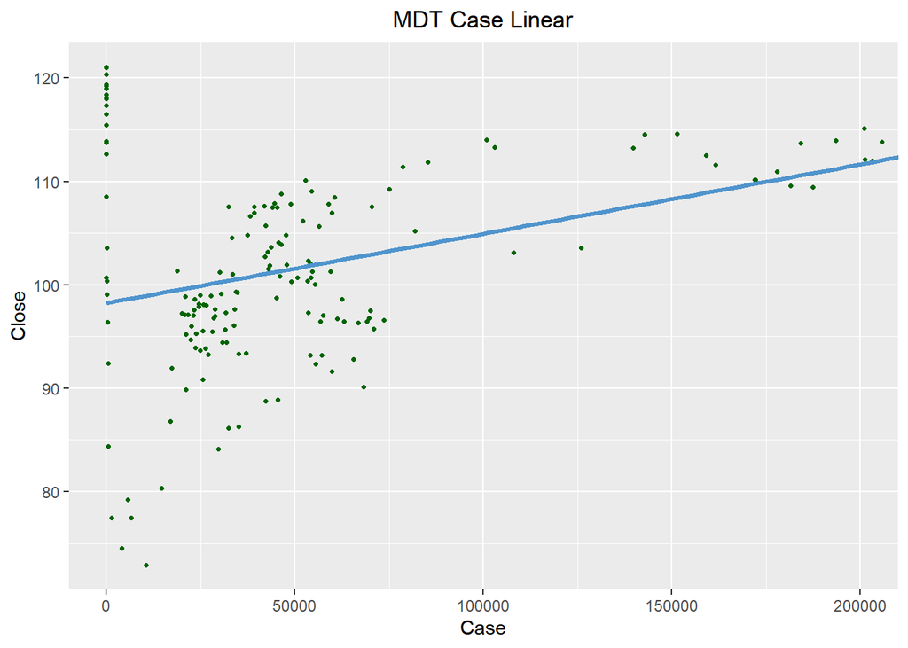

```r
MDT_case = select(MDT_2020,Close,Case)
MDT_train_case= MDT_case[split,]
MDT_test_case= MDT_case[-split,]

MDT_model_A = lm(Close ~ Case,MDT_train_case)

ggplot(data=MDT_train_case,aes(x=Case,y=Close))+
  geom_point(color='darkgreen',size=0.9)+
  geom_smooth(method="lm",size=1.2,color="steelblue3",se=FALSE)+
  coord_cartesian(xlim=c(0,200000))+ ggtitle("MDT Case Linear")+
  theme(plot.title = element_text(hjust = 0.5))
```

```r
pred_MDT_A1 = predict(MDT_model_A)
rmse_MDT_A1 = sqrt(mean((pred_MDT_A1 - MDT_train_case$Close)^2))
rmse_MDT_A1
```

```
## [1] 8.886416
```

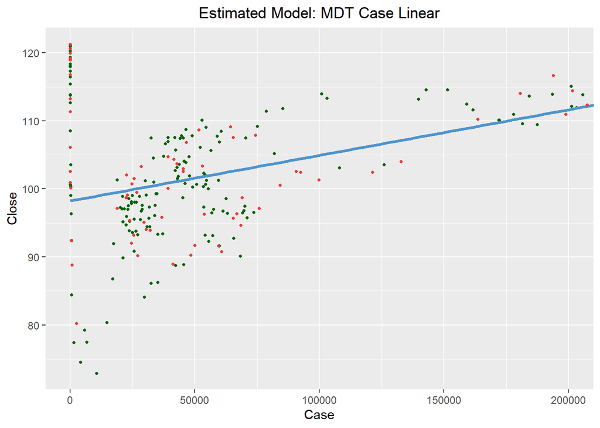

```r
pred_MDT_A2 = predict(MDT_model_A,newdata = MDT_test_case)

ggplot(data=MDT_train_case,aes(x=Case,y=Close))+
  geom_point(color='darkgreen',size=0.9)+
  geom_smooth(method="lm",size=1.2,color="steelblue3",se=FALSE)+
  geom_point(data=MDT_test_case,aes(x=Case,y=Close),color='brown2',size=0.9)+
  coord_cartesian(xlim=c(0,200000))+ theme(plot.title = element_text(hjust = 0.5)) + ggtitle("Estimated Model: MDT Case Linear")
```

```r
rmse_MDT_A2 = sqrt(mean((pred_MDT_A2 - MDT_test_case$Close)^2))
rmse_MDT_A2
```

```
## [1] 8.885786
```

For medtronic, a linear fit has been conducted first to examine the coorelation and ends up having the case change significant to the stock price change with pvalue = 6.93e-10. Then, a linear model has been trained and tested. The RMSE value got from the training is 8.886416 and the RMSE value for the testing dataset is 8.885786, which matched perfectly with each other, indicating the correctness of the linear model for medtronic based on 2020 case increase

```r
MDT_test_d = lm(MDT_2020$Close ~ MDT_2020$Death)
summary(MDT_test_d)
```

```
##
## Call:
## lm(formula = MDT_2020$Close ~ MDT_2020$Death)
##
## Residuals:
##      Min       1Q   Median       3Q      Max
## -28.1754  -6.3944  -0.5359   7.0432  20.4995
##
## Coefficients:
##                 Estimate Std. Error t value Pr(>|t|)
## (Intercept)    1.008e+02  1.031e+00  97.808   <2e-16 ***
## MDT_2020$Death 1.432e-03  7.105e-04   2.015   0.0451 *
## ---
## Signif. codes:  0 '***' 0.001 '**' 0.01 '*' 0.05 '.' 0.1 ' ' 1
##
## Residual standard error: 9.564 on 238 degrees of freedom
## Multiple R-squared:  0.01677,    Adjusted R-squared:  0.01264
## F-statistic: 4.059 on 1 and 238 DF,  p-value: 0.04505
```

```r
confint(MDT_test_d)
```

```
##                       2.5 %       97.5 %
## (Intercept)    9.877029e+01 1.028308e+02
## MDT_2020$Death 3.183732e-05 2.831282e-03
```

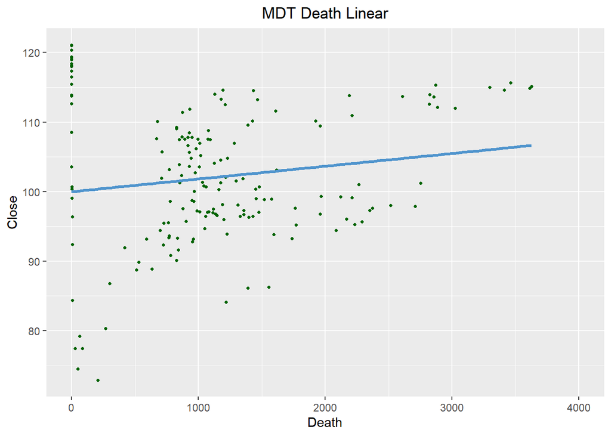

```r
MDT_death = select(MDT_2020,Close,Death)
MDT_train_death= MDT_death[split,]
MDT_test_death= MDT_death[-split,]

MDT_model_B = lm(Close ~ Death,MDT_train_death)

ggplot(data=MDT_train_death,aes(x=Death,y=Close))+
  geom_point(color='darkgreen',size=0.9)+
  geom_smooth(method="lm",size=1.2,color="steelblue3",se=FALSE)+
  coord_cartesian(xlim=c(0,4000))+ ggtitle("MDT Death Linear")+
  theme(plot.title = element_text(hjust = 0.5))
```

```r
pred_MDT_B1 = predict(MDT_model_B)
rmse_MDT_B1 = sqrt(mean((pred_MDT_B1 - MDT_train_death$Close)^2))
rmse_MDT_B1
```

```
## [1] 9.640908
```

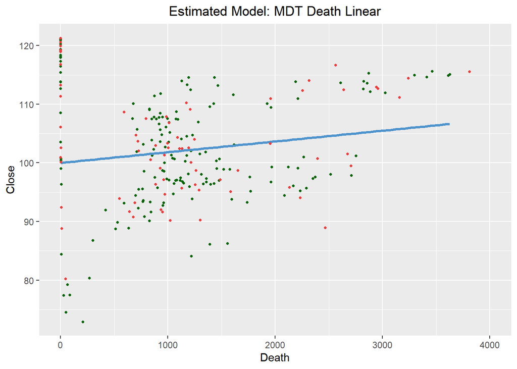

```r
pred_MDT_B2 = predict(MDT_model_B,newdata = MDT_test_death)

ggplot(data=MDT_train_death,aes(x=Death,y=Close))+
  geom_point(color='darkgreen',size=0.9)+
  geom_smooth(method="lm",size=1.2,color="steelblue3",se=FALSE)+
  geom_point(data=MDT_test_death,aes(x=Death,y=Close),color='brown2',size=0.9)+
  coord_cartesian(xlim=c(0,4000))+ theme(plot.title = element_text(hjust = 0.5)) + ggtitle("Estimated Model: MDT Death Linear")
```

```r
rmse_MDT_B2 = sqrt(mean((pred_MDT_B2 - MDT_test_death$Close)^2))
rmse_MDT_B2
```

```
## [1] 9.289378
```

From the table and the result, it can be seen that even though with higher p_valuem, the death change in 2020 is still significant to the stock price change of medtronic, less significant than the case change. Also, the RMSE for this model is also low and close together, indictating the correctness of the model.

```r
SYK_test_c = lm(SYK_2020$Close ~ SYK_2020$Case)
summary(SYK_test_c)
```

```
##
## Call:
## lm(formula = SYK_2020$Close ~ SYK_2020$Case)
##
## Residuals:
##     Min      1Q  Median      3Q     Max
## -61.955  -9.219  -0.650  10.746  39.001
##
## Coefficients:
##                Estimate Std. Error t value Pr(>|t|)
## (Intercept)   1.861e+02  1.615e+00  115.26   <2e-16 ***
## SYK_2020$Case 2.258e-04  1.850e-05   12.21   <2e-16 ***
## ---
## Signif. codes:  0 '***' 0.001 '**' 0.01 '*' 0.05 '.' 0.1 ' ' 1
##
## Residual standard error: 18.19 on 238 degrees of freedom
## Multiple R-squared:  0.385,  Adjusted R-squared:  0.3824
## F-statistic:   149 on 1 and 238 DF,  p-value: < 2.2e-16
```

```r
confint(SYK_test_c)
```

```
##                      2.5 %       97.5 %
## (Intercept)   1.829179e+02 1.892792e+02
## SYK_2020$Case 1.893948e-04 2.622933e-04
```

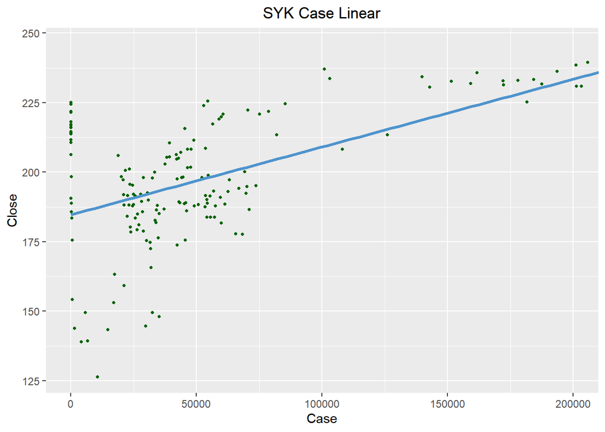

```r
SYK_case = select(SYK_2020,Close,Case)
SYK_train_case= SYK_case[split,]
SYK_test_case= SYK_case[-split,]

SYK_model_A = lm(Close ~ Case,SYK_train_case)

ggplot(data=SYK_train_case,aes(x=Case,y=Close))+
  geom_point(color='darkgreen',size=0.9)+
  geom_smooth(method="lm",size=1.2,color="steelblue3",se=FALSE)+
  coord_cartesian(xlim=c(0,200000))+ ggtitle("SYK Case Linear")+
  theme(plot.title = element_text(hjust = 0.5))
```

```r
pred_SYK_A1 = predict(SYK_model_A)
rmse_SYK_A1 = sqrt(mean((pred_SYK_A1 - SYK_train_case$Close)^2))
rmse_SYK_A1
```

```
## [1] 18.50596
```

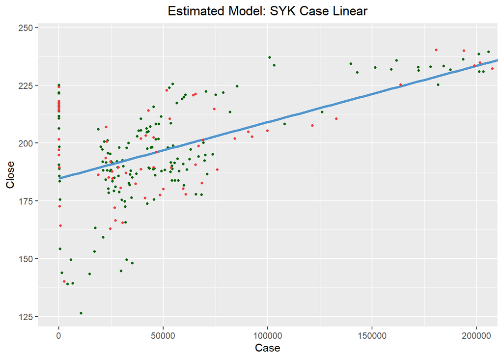

```r
pred_SYK_A2 = predict(SYK_model_A,newdata = SYK_test_case)

ggplot(data=SYK_train_case,aes(x=Case,y=Close))+
  geom_point(color='darkgreen',size=0.9)+
  geom_smooth(method="lm",size=1.2,color="steelblue3",se=FALSE)+
  geom_point(data=SYK_test_case,aes(x=Case,y=Close),color='brown2',size=0.9)+
  coord_cartesian(xlim=c(0,200000))+ theme(plot.title = element_text(hjust = 0.5)) + ggtitle("Estimated Model: SYK Case Linear")
```

```r
rmse_SYK_A2 = sqrt(mean((pred_SYK_A2 - SYK_test_case$Close)^2))
rmse_SYK_A2
```

```
## [1] 17.30224
```

For Stryker, a linear fit has been conducted first to examine the coorelation and ends up having the case change significant to the stock price change with pvalue =2.2e-16. Then, a linear model has been trained and tested. The RMSE value got from the training is 18.5 and the RMSE value for the testing dataset is 17.30, which are larger than Medtronic but can still consdiered as valid and the case increase is more significnat to stryker than medtronic.

```r
SYK_test_d = lm(SYK_2020$Close ~ SYK_2020$Death)
summary(SYK_test_d)
```

```
##
## Call:
## lm(formula = SYK_2020$Close ~ SYK_2020$Death)
##
## Residuals:
##     Min      1Q  Median      3Q     Max
## -66.044 -14.130  -0.049  21.104  37.675
##
## Coefficients:
##                 Estimate Std. Error t value Pr(>|t|)
## (Intercept)    1.910e+02  2.400e+00  79.578  < 2e-16 ***
## SYK_2020$Death 7.412e-03  1.655e-03   4.479 1.17e-05 ***
## ---
## Signif. codes:  0 '***' 0.001 '**' 0.01 '*' 0.05 '.' 0.1 ' ' 1
##
## Residual standard error: 22.28 on 238 degrees of freedom
## Multiple R-squared:  0.07773,    Adjusted R-squared:  0.07385
## F-statistic: 20.06 on 1 and 238 DF,  p-value: 1.166e-05
```

```r
confint(SYK_test_d)
```

```
##                       2.5 %      97.5 %
## (Intercept)    1.862883e+02 195.7456357
## SYK_2020$Death 4.151665e-03   0.0106719
```

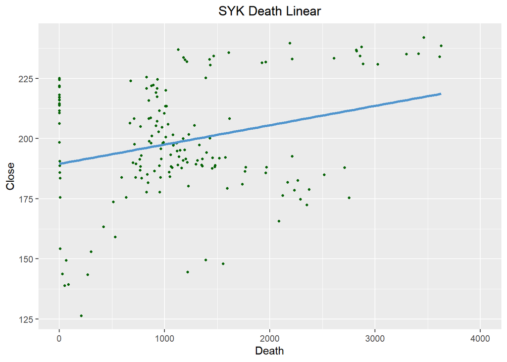

```r
SYK_death = select(SYK_2020,Close,Death)
SYK_train_death= SYK_death[split,]
SYK_test_death= SYK_death[-split,]

SYK_model_B = lm(Close ~ Death,SYK_train_death)

ggplot(data=SYK_train_death,aes(x=Death,y=Close))+
  geom_point(color='darkgreen',size=0.9)+
  geom_smooth(method="lm",size=1.2,color="steelblue3",se=FALSE)+
  coord_cartesian(xlim=c(0,4000))+ ggtitle("SYK Death Linear")+
  theme(plot.title = element_text(hjust = 0.5))
```

```r
pred_SYK_B1 = predict(SYK_model_B)
rmse_SYK_B1 = sqrt(mean((pred_SYK_B1 - SYK_train_death$Close)^2))
rmse_SYK_B1
```

```
## [1] 22.65378
```

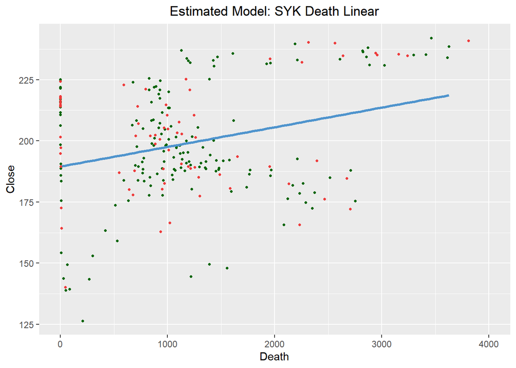

```r
pred_SYK_B2 = predict(SYK_model_B,newdata = SYK_test_death)

ggplot(data=SYK_train_death,aes(x=Death,y=Close))+
  geom_point(color='darkgreen',size=0.9)+
  geom_smooth(method="lm",size=1.2,color="steelblue3",se=FALSE)+
  geom_point(data=SYK_test_death,aes(x=Death,y=Close),color='brown2',size=0.9)+
  coord_cartesian(xlim=c(0,4000))+ theme(plot.title = element_text(hjust = 0.5)) + ggtitle("Estimated Model: SYK Death Linear")
```

```r
rmse_SYK_B2 = sqrt(mean((pred_SYK_B2 - SYK_test_death$Close)^2))
rmse_SYK_B2
```

```
## [1] 21.11641
```

Based on the result, it shows that death change is considered as significant to stryker but the model is less accurate compared to the previous three with higher RMSE value at approximately 22.

```r
BSX_test_c = lm(BSX_2020$Close ~ BSX_2020$Case)
summary(BSX_test_c)
```

```
##
## Call:
## lm(formula = BSX_2020$Close ~ BSX_2020$Case)
##
## Residuals:
##     Min      1Q  Median      3Q     Max
## -11.980  -1.656   0.017   2.025   6.099
##
## Coefficients:
##                 Estimate Std. Error t value Pr(>|t|)
## (Intercept)    3.797e+01  2.892e-01 131.291  < 2e-16 ***
## BSX_2020$Case -1.540e-05  3.314e-06  -4.647 5.57e-06 ***
## ---
## Signif. codes:  0 '***' 0.001 '**' 0.01 '*' 0.05 '.' 0.1 ' ' 1
##
## Residual standard error: 3.258 on 238 degrees of freedom
## Multiple R-squared:  0.0832, Adjusted R-squared:  0.07934
## F-statistic:  21.6 on 1 and 238 DF,  p-value: 5.571e-06
```

```r
confint(BSX_test_c)
```

```
##                       2.5 %        97.5 %
## (Intercept)    3.740076e+01  3.854023e+01
## BSX_2020$Case -2.193135e-05 -8.873385e-06
```

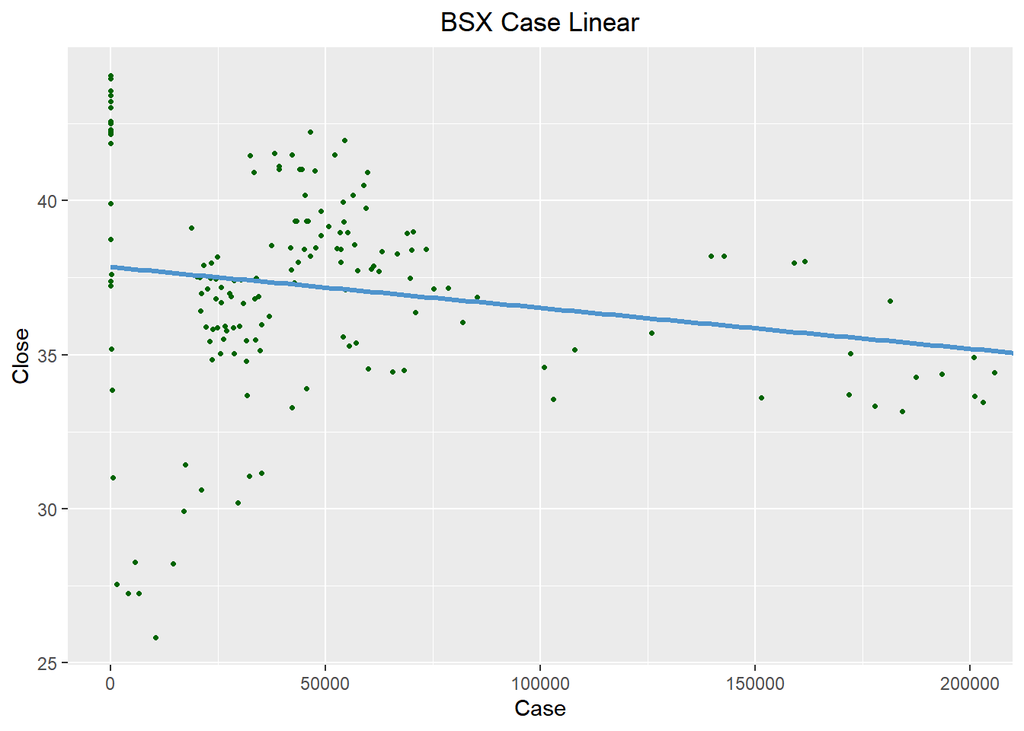

```r
BSX_case = select(BSX_2020,Close,Case)
BSX_train_case= BSX_case[split,]
BSX_test_case= BSX_case[-split,]

BSX_model_A = lm(Close ~ Case,BSX_train_case)

ggplot(data=BSX_train_case,aes(x=Case,y=Close))+
  geom_point(color='darkgreen',size=0.9)+
  geom_smooth(method="lm",size=1.2,color="steelblue3",se=FALSE)+
  coord_cartesian(xlim=c(0,200000))+ ggtitle("BSX Case Linear")+
  theme(plot.title = element_text(hjust = 0.5))
```

```r
pred_BSX_A1 = predict(BSX_model_A)
rmse_BSX_A1 = sqrt(mean((pred_BSX_A1 - BSX_train_case$Close)^2))
rmse_BSX_A1
```

```
## [1] 3.397912
```

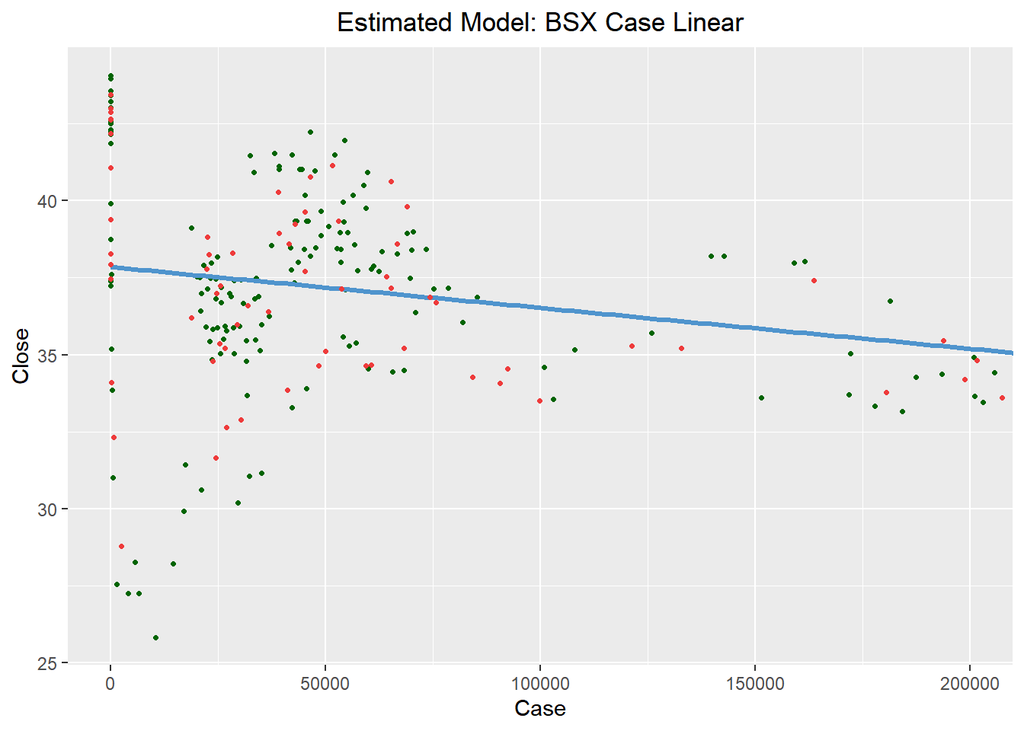

```r
pred_BSX_A2 = predict(BSX_model_A,newdata = BSX_test_case)

ggplot(data=BSX_train_case,aes(x=Case,y=Close))+
  geom_point(color='darkgreen',size=0.9)+
  geom_smooth(method="lm",size=1.2,color="steelblue3",se=FALSE)+
  geom_point(data=BSX_test_case,aes(x=Case,y=Close),color='brown2',size=0.9)+
  coord_cartesian(xlim=c(0,200000))+ theme(plot.title = element_text(hjust = 0.5)) + ggtitle("Estimated Model: BSX Case Linear")
```

```r
rmse_BSX_A2 = sqrt(mean((pred_BSX_A2 - BSX_test_case$Close)^2))
rmse_BSX_A2
```

```
## [1] 2.866701
```

The linear model for Boston Scientific has the RMSE of 3.397912, which is currently the lowest compared to the other 4 models and the case change is considered as important to Boston Scientific

```r
BSX_test_d = lm(BSX_2020$Close ~ BSX_2020$Death)
summary(BSX_test_d)
```

```
##
## Call:
## lm(formula = BSX_2020$Close ~ BSX_2020$Death)
##
## Residuals:
##      Min       1Q   Median       3Q      Max
## -12.3741  -1.4081   0.3467   1.9628   5.6166
##
## Coefficients:
##                  Estimate Std. Error t value Pr(>|t|)
## (Intercept)    38.4533923  0.3486000 110.308  < 2e-16 ***
## BSX_2020$Death -0.0012101  0.0002403  -5.035 9.44e-07 ***
## ---
## Signif. codes:  0 '***' 0.001 '**' 0.01 '*' 0.05 '.' 0.1 ' ' 1
##
## Residual standard error: 3.235 on 238 degrees of freedom
## Multiple R-squared:  0.09626,    Adjusted R-squared:  0.09246
## F-statistic: 25.35 on 1 and 238 DF,  p-value: 9.441e-07
```

```r
confint(BSX_test_d)
```

```
##                      2.5 %        97.5 %
## (Intercept)    37.76665677 39.1401277815
## BSX_2020$Death -0.00168353 -0.0007366131
```

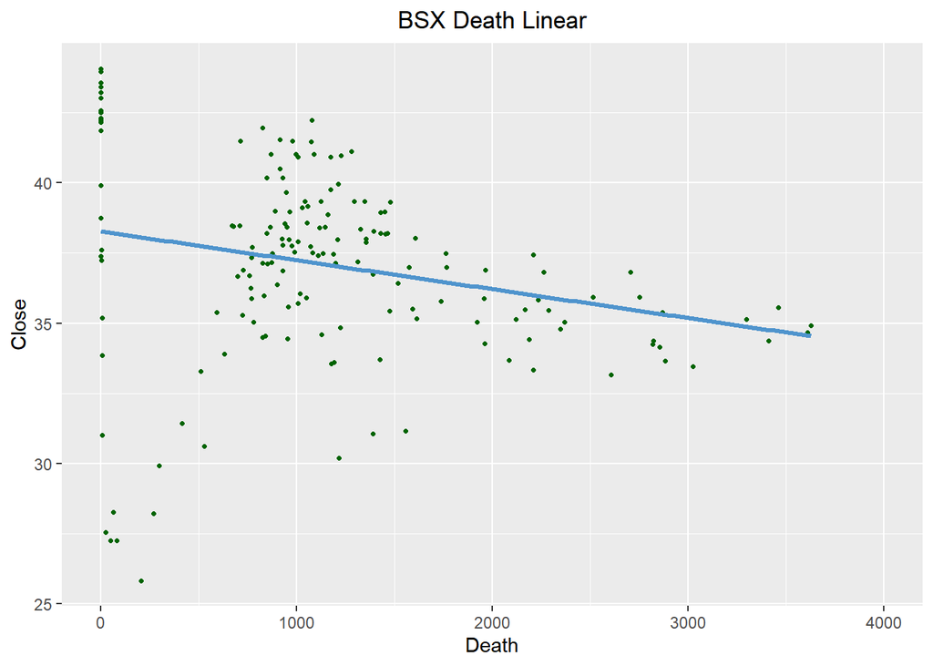

```r
BSX_death = select(BSX_2020,Close,Death)
BSX_train_death= BSX_death[split,]
BSX_test_death= BSX_death[-split,]

BSX_model_B = lm(Close ~ Death,BSX_train_death)

ggplot(data=BSX_train_death,aes(x=Death,y=Close))+
  geom_point(color='darkgreen',size=0.9)+
  geom_smooth(method="lm",size=1.2,color="steelblue3",se=FALSE)+
  coord_cartesian(xlim=c(0,4000))+ ggtitle("BSX Death Linear")+
  theme(plot.title = element_text(hjust = 0.5))
```

```r
pred_BSX_B1 = predict(BSX_model_B)
rmse_BSX_B1 = sqrt(mean((pred_BSX_B1 - BSX_train_death$Close)^2))
rmse_BSX_B1
```

```
## [1] 3.383585
```

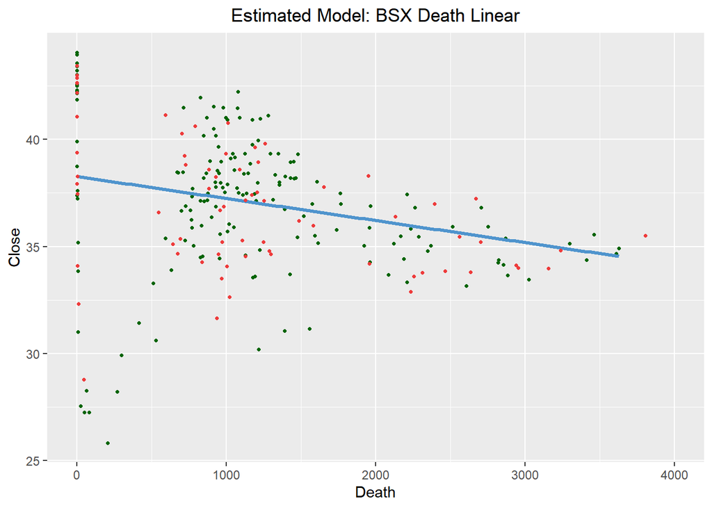

```r
pred_BSX_B2 = predict(BSX_model_B,newdata = BSX_test_death)

ggplot(data=BSX_train_death,aes(x=Death,y=Close))+
  geom_point(color='darkgreen',size=0.9)+
  geom_smooth(method="lm",size=1.2,color="steelblue3",se=FALSE)+
  geom_point(data=BSX_test_death,aes(x=Death,y=Close),color='brown2',size=0.9)+
  coord_cartesian(xlim=c(0,4000))+ theme(plot.title = element_text(hjust = 0.5)) + ggtitle("Estimated Model: BSX Death Linear")
```

```r
rmse_BSX_B2 = sqrt(mean((pred_BSX_B2 - BSX_test_death$Close)^2))
rmse_BSX_B2
```

```
## [1] 2.822899
```

Same situation also occured for the death change with low RMSE value, it indicate that the linear model for Boston Scientific is currently the most accurate model to predict the stock price now.

```r
ZBH_test_case = lm(ZBH_2020$Close ~ ZBH_2020$Case)
summary(ZBH_test_case)
```

```
##
## Call:
## lm(formula = ZBH_2020$Close ~ ZBH_2020$Case)
##
## Residuals:
##     Min      1Q  Median      3Q     Max
## -46.800  -9.090   1.610   8.592  33.848
##
## Coefficients:
##                Estimate Std. Error t value Pr(>|t|)
## (Intercept)   1.266e+02  1.417e+00  89.298  < 2e-16 ***
## ZBH_2020$Case 1.014e-04  1.624e-05   6.246 1.93e-09 ***
## ---
## Signif. codes:  0 '***' 0.001 '**' 0.01 '*' 0.05 '.' 0.1 ' ' 1
##
## Residual standard error: 15.97 on 238 degrees of freedom
## Multiple R-squared:  0.1408, Adjusted R-squared:  0.1372
## F-statistic: 39.01 on 1 and 238 DF,  p-value: 1.925e-09
```

```r
confint(ZBH_test_case)
```

```
##                      2.5 %       97.5 %
## (Intercept)   1.237601e+02 1.293438e+02
## ZBH_2020$Case 6.943971e-05 1.334271e-04
```

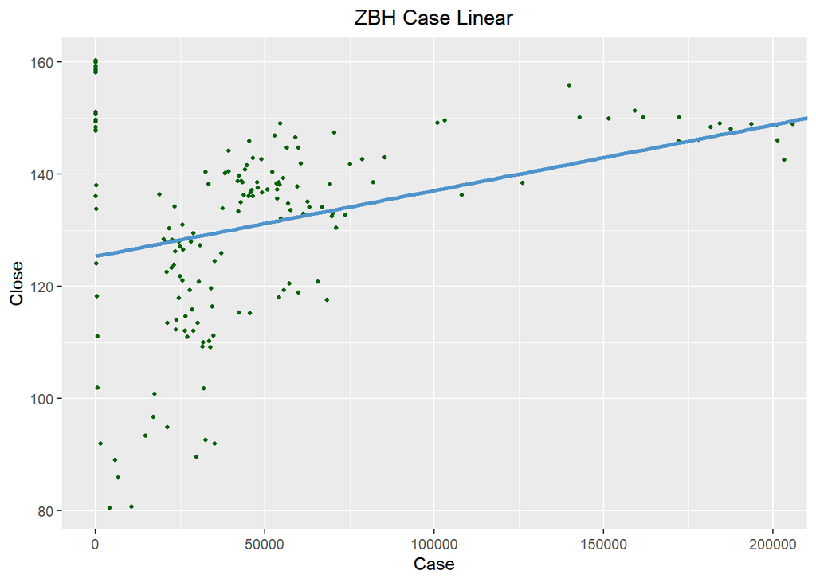

```r
ZBH_case = select(ZBH_2020,Close,Case)
ZBH_train_case= ZBH_case[split,]
ZBH_test_case= ZBH_case[-split,]

ZBH_model_A = lm(Close ~ Case,ZBH_train_case)

ggplot(data=ZBH_train_case,aes(x=Case,y=Close))+
  geom_point(color='darkgreen',size=0.9)+
  geom_smooth(method="lm",size=1.2,color="steelblue3",se=FALSE)+
  coord_cartesian(xlim=c(0,200000))+ ggtitle("ZBH Case Linear")+
  theme(plot.title = element_text(hjust = 0.5))
```

```r
pred_ZBH_A1 = predict(ZBH_model_A)
rmse_ZBH_A1 = sqrt(mean((pred_ZBH_A1 - ZBH_train_case$Close)^2))
rmse_ZBH_A1
```

```
## [1] 15.95196
```

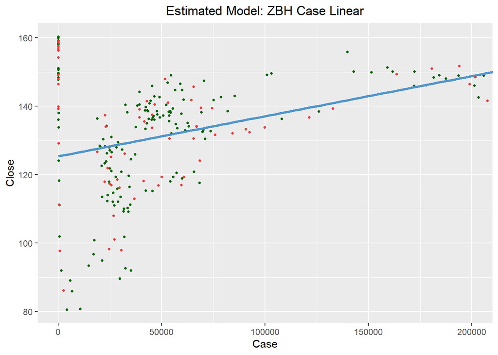

```r
pred_ZBH_A2 = predict(ZBH_model_A,newdata = ZBH_test_case)

ggplot(data=ZBH_train_case,aes(x=Case,y=Close))+
  geom_point(color='darkgreen',size=0.9)+
  geom_smooth(method="lm",size=1.2,color="steelblue3",se=FALSE)+
  geom_point(data=ZBH_test_case,aes(x=Case,y=Close),color='brown2',size=0.9)+
  coord_cartesian(xlim=c(0,200000))+ theme(plot.title = element_text(hjust = 0.5)) + ggtitle("Estimated Model: ZBH Case Linear")
```

```r
rmse_ZBH_A2 = sqrt(mean((pred_ZBH_A2 - ZBH_test_case$Close)^2))
rmse_ZBH_A2
```

```
## [1] 15.89043
```

From the summary, it shows that daily case increase is signifcant to zimmer’s stock price with relatively high RMSE value (15.95 and 15.89) compared to the other three companies but it is still acceptable in this case.

```r
# Not significant P value larger than 0.05
ZBH_test_d = lm(ZBH_2020$Close ~ ZBH_2020$Death)
summary(ZBH_test_d)
```

```
##
## Call:
## lm(formula = ZBH_2020$Close ~ ZBH_2020$Death)
##
## Residuals:
##     Min      1Q  Median      3Q     Max
## -51.721 -11.748   3.858  13.360  28.061
##
## Coefficients:
##                 Estimate Std. Error t value Pr(>|t|)
## (Intercept)    1.323e+02  1.856e+00  71.302   <2e-16 ***
## ZBH_2020$Death 2.480e-04  1.280e-03   0.194    0.846
## ---
## Signif. codes:  0 '***' 0.001 '**' 0.01 '*' 0.05 '.' 0.1 ' ' 1
##
## Residual standard error: 17.22 on 238 degrees of freedom
## Multiple R-squared:  0.0001579,  Adjusted R-squared:  -0.004043
## F-statistic: 0.03758 on 1 and 238 DF,  p-value: 0.8465
```

```r
confint(ZBH_test_d)
```

```
##                       2.5 %       97.5 %
## (Intercept)    128.68264719 1.359954e+02
## ZBH_2020$Death  -0.00227277 2.768857e-03
```

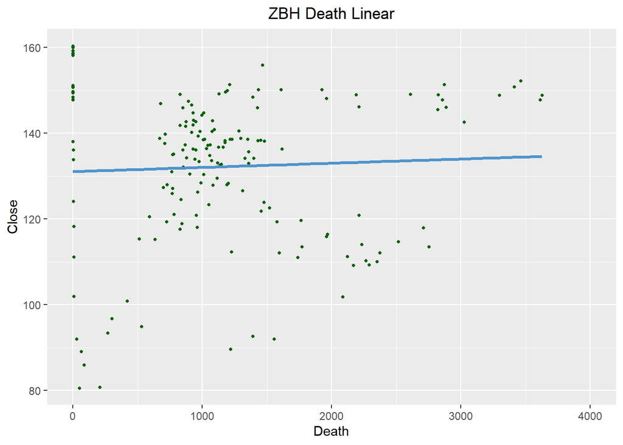

```r
ZBH_death = select(ZBH_2020,Close,Death)
ZBH_train_death= ZBH_death[split,]
ZBH_test_death= ZBH_death[-split,]

ZBH_model_B = lm(Close ~ Death,ZBH_train_death)

ggplot(data=ZBH_train_death,aes(x=Death,y=Close))+
  geom_point(color='darkgreen',size=0.9)+
  geom_smooth(method="lm",size=1.2,color="steelblue3",se=FALSE)+
  coord_cartesian(xlim=c(0,4000))+ ggtitle("ZBH Death Linear")+
  theme(plot.title = element_text(hjust = 0.5))
```

```r
pred_ZBH_B1 = predict(ZBH_model_B)
rmse_ZBH_B1 = sqrt(mean((pred_ZBH_B1 - ZBH_train_death$Close)^2))
rmse_ZBH_B1
```

```
## [1] 17.42696
```

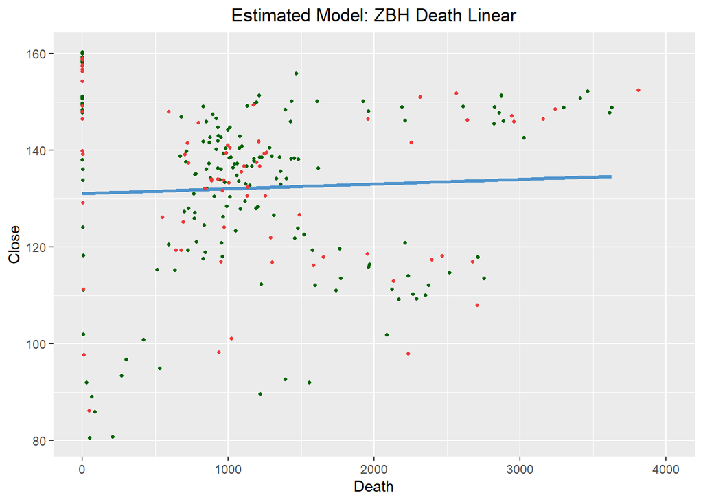

```r
pred_ZBH_B2 = predict(ZBH_model_B,newdata = ZBH_test_death)

ggplot(data= ZBH_train_death,aes(x=Death,y=Close))+
  geom_point(color='darkgreen',size=0.9)+
  geom_smooth(method="lm",size=1.2,color="steelblue3",se=FALSE)+
  geom_point(data=ZBH_test_death,aes(x=Death,y=Close),color='brown2',size=0.9)+
  coord_cartesian(xlim=c(0,4000))+ theme(plot.title = element_text(hjust = 0.5)) + ggtitle("Estimated Model: ZBH Death Linear")
```

```r
rmse_ZBH_B2 = sqrt(mean((pred_ZBH_B2 - ZBH_test_death$Close)^2))
rmse_ZBH_B2
```

```
## [1] 16.5554
```

it is interesting to see that based on the linear fit, the p_value equals 0.8465, indicating that the daily death increase are not significant to the stock price change for Zimmer Bionmet and the RMSE value for the model is relatively high. However, I decided to still include this model as the RMSE value still falls in the accepted range.

```r
set.seed(1031)
RF_split = createDataPartition(y = MDT_case$Close, p = 0.75, list = F,groups = 10)
MDT_RF_Ctrain = MDT_case[split,]
MDT_RF_Ctest = MDT_case[-split,]

MDT_cforest = randomForest(Close~.,data = MDT_RF_Ctrain,ntree = 1000)

pred_rf_cMDT =predict(MDT_cforest)
rmse_rf_cMDT =sqrt(mean((pred_rf_cMDT - MDT_RF_Ctrain$Close)^2))
rmse_rf_cMDT
```

```
## [1] 5.494711
```

```r
pred_forest_MDT_case = predict(MDT_cforest, newdata = MDT_RF_Ctest)
rmse_forest_MDT_case = sqrt(mean((pred_forest_MDT_case - MDT_RF_Ctest$Close)^2))
rmse_forest_MDT_case
```

```
## [1] 5.757696
```

For Medtronic and the daily case increas, the RMSE value is smaller compared to the linear regression, indicating that the random forest model is more accurate in this case. Similar Situation also occured for medtronic and the daily death increase in 2020 with smaller RMSE value compared to the linear model, indicating more accurate model.

```r
set.seed(1031)
RF_split = createDataPartition(y = MDT_death$Close, p = 0.75, list = F,groups = 10)
MDT_RF_dtrain = MDT_death[split,]
MDT_RF_dtest = MDT_death[-split,]

MDT_dforest = randomForest(Close~.,data = MDT_RF_dtrain,ntree = 1000)

pred_rf_dMDT =predict(MDT_dforest)
rmse_rf_dMDT =sqrt(mean((pred_rf_dMDT - MDT_RF_dtrain$Close)^2))
rmse_rf_dMDT
```

```
## [1] 7.220115
```

```r
pred_forest_MDT_death = predict(MDT_dforest, newdata = MDT_RF_dtest)
rmse_forest_MDT_death = sqrt(mean((pred_forest_MDT_death - MDT_RF_dtest$Close)^2))
rmse_forest_MDT_death
```

```
## [1] 7.243959
```

Similar situation also occured for Stryker with the daily case increase with the training and testing RMSE and 13.9 and 13.5, indicating more accurate model compared to the linear regression model.

```r
set.seed(1031)
RF_split = createDataPartition(y = SYK_case$Close, p = 0.75, list = F,groups = 10)
SYK_RF_Ctrain = SYK_case[split,]
SYK_RF_Ctest = SYK_case[-split,]

SYK_cforest = randomForest(Close~.,data = SYK_RF_Ctrain,ntree = 1000)

pred_rf_cSYK =predict(SYK_cforest)
rmse_rf_cSYK =sqrt(mean((pred_rf_cSYK - SYK_RF_Ctrain$Close)^2))
rmse_rf_cSYK
```

```
## [1] 13.93184
```

```r
pred_forest_SYK_case = predict(SYK_cforest, newdata = SYK_RF_Ctest)
rmse_forest_SYK_case = sqrt(mean((pred_forest_SYK_case - SYK_RF_Ctest$Close)^2))
rmse_forest_SYK_case
```

```
## [1] 13.51217
```

RMSE value for the Stryker and the death change in Random Forest are slightly lower, means better model.

```r
set.seed(1031)
RF_split = createDataPartition(y = SYK_death$Close, p = 0.75, list = F,groups = 10)
SYK_RF_dtrain = SYK_death[split,]
SYK_RF_dtest = SYK_death[-split,]

SYK_dforest = randomForest(Close~.,data = SYK_RF_dtrain,ntree = 1000)

pred_rf_dSYK =predict(SYK_dforest)
rmse_rf_dSYK =sqrt(mean((pred_rf_dSYK - SYK_RF_dtrain$Close)^2))
rmse_rf_dSYK
```

```
## [1] 19.28245
```

```r
pred_forest_SYK_death = predict(SYK_dforest, newdata = SYK_RF_dtest)
rmse_forest_SYK_death = sqrt(mean((pred_forest_SYK_death - SYK_RF_dtest$Close)^2))
rmse_forest_SYK_death
```

```
## [1] 20.11605
```

The RMSE value using Random Forest for Boston Scientific are significantly smaller than the linear model, potential leading to a better result.

```r
set.seed(1031)
RF_split = createDataPartition(y = BSX_case$Close, p = 0.75, list = F,groups = 10)
BSX_RF_Ctrain = BSX_case[split,]
BSX_RF_Ctest = BSX_case[-split,]

BSX_cforest = randomForest(Close~.,data = BSX_RF_Ctrain,ntree = 1000)

pred_rf_cBSX =predict(BSX_cforest)
rmse_rf_cBSX =sqrt(mean((pred_rf_cBSX - BSX_RF_Ctrain$Close)^2))
rmse_rf_cBSX
```

```
## [1] 2.344312
```

```r
pred_forest_BSX_case = predict(BSX_cforest, newdata = BSX_RF_Ctest)
rmse_forest_BSX_case = sqrt(mean((pred_forest_BSX_case - BSX_RF_Ctest$Close)^2))
rmse_forest_BSX_case
```

```
## [1] 1.920912
```

Similar situation occured her for the Boston Scientific with significant lower RMSE value, indicating for better model than the linear regression.

```r
set.seed(1031)
RF_split = createDataPartition(y = BSX_death$Close, p = 0.75, list = F,groups = 10)
BSX_RF_dtrain = BSX_death[split,]
BSX_RF_dtest = BSX_death[-split,]

BSX_dforest = randomForest(Close~.,data = BSX_RF_dtrain,ntree = 1000)

pred_rf_dBSX =predict(BSX_dforest)
rmse_rf_dBSX =sqrt(mean((pred_rf_dBSX - BSX_RF_dtrain$Close)^2))
rmse_rf_dBSX
```

```
## [1] 2.343616
```

```r
pred_forest_BSX_death = predict(BSX_dforest, newdata = BSX_RF_dtest)
rmse_forest_BSX_death = sqrt(mean((pred_forest_BSX_death - BSX_RF_dtest$Close)^2))
rmse_forest_BSX_death
```

```
## [1] 2.507254
```

Zimmer has the similar result as the other companies with the case change, smaller RMSE value compared to linear model.

```r
set.seed(1031)

RF_split = createDataPartition(y = ZBH_case$Close, p = 0.75, list = F,groups = 10)
ZBH_RF_Ctrain = ZBH_case[split,]
ZBH_RF_Ctest = ZBH_case[-split,]

ZBH_cforest = randomForest(Close~.,data = ZBH_RF_Ctrain,ntree = 1000)

pred_rf_cZBH =predict(ZBH_cforest)
rmse_rf_cZBH =sqrt(mean((pred_rf_cZBH - ZBH_RF_Ctrain$Close)^2))
rmse_rf_cZBH
```

```
## [1] 10.36587
```

```r
pred_forest_ZBH_case = predict(ZBH_cforest, newdata = ZBH_RF_Ctest)
rmse_forest_ZBH_case = sqrt(mean((pred_forest_ZBH_case - ZBH_RF_Ctest$Close)^2))
rmse_forest_ZBH_case
```

```
## [1] 9.234159
```

```r
set.seed(1031)
RF_split = createDataPartition(y = ZBH_death$Close, p = 0.75, list = F,groups = 10)
ZBH_RF_dtrain = ZBH_death[split,]
ZBH_RF_dtest = ZBH_death[-split,]

ZBH_dforest = randomForest(Close~.,data = ZBH_RF_dtrain,ntree = 1000)

pred_rf_dZBH =predict(ZBH_dforest)
rmse_rf_dZBH =sqrt(mean((pred_rf_dZBH - ZBH_RF_dtrain$Close)^2))
rmse_rf_dZBH
```

```
## [1] 13.22968
```

```r
pred_forest_ZBH_death = predict(BSX_dforest, newdata = BSX_RF_dtest)
rmse_forest_ZBH_death = sqrt(mean((pred_forest_ZBH_death - ZBH_RF_dtest$Close)^2))
rmse_forest_ZBH_death
```

```
## [1] 97.31514
```

#Prediction Actual 2021 stock price to Dec 2, 2021 has been uploaded here and merged with the COVID19 2021 case and death increase.

```r
MDT_2021$Date = as.character(MDT_2021$Date)
MDT_2021_case = merge(US_2021_Case,MDT_2021, by = "Date")
MDT_2021_death = merge(US_2021_Death,MDT_2021, by = "Date")

SYK_2021$Date = as.character(SYK_2021$Date)
SYK_2021_case = merge(US_2021_Case,SYK_2021, by = "Date")
SYK_2021_death = merge(US_2021_Death,SYK_2021, by = "Date")

BSX_2021$Date = as.character(BSX_2021$Date)
BSX_2021_case = merge(US_2021_Case,BSX_2021, by = "Date")
BSX_2021_death = merge(US_2021_Death,BSX_2021, by = "Date")

ZBH_2021$Date = as.character(ZBH_2021$Date)
ZBH_2021_case = merge(US_2021_Case,ZBH_2021, by = "Date")
ZBH_2021_death = merge(US_2021_Death,ZBH_2021, by = "Date")
```

2021 Covid-19 Case and Death in US

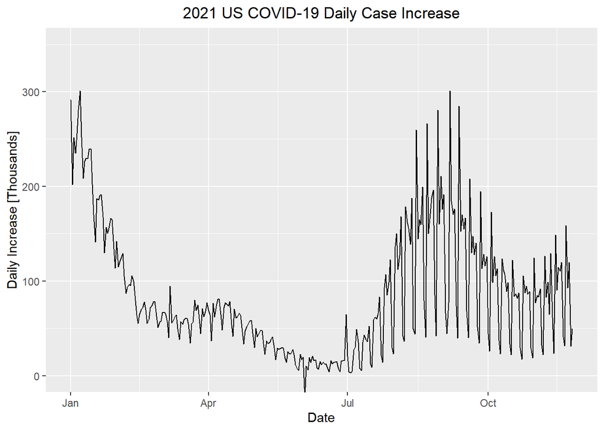

```r
US_2021_Case = na.omit(US_2021_Case)
US_2021_Case$Date = as.Date(US_2021_Case$Date)
ggplot()+geom_line(aes(Date,Case/1000,group = 1),data = US_2021_Case)+
  coord_cartesian(ylim=c(0,350)) + ylab("Daily Increase [Thousands]") + ggtitle("2021 US COVID-19 Daily Case Increase")+ theme(plot.title = element_text(hjust = 0.5))
```

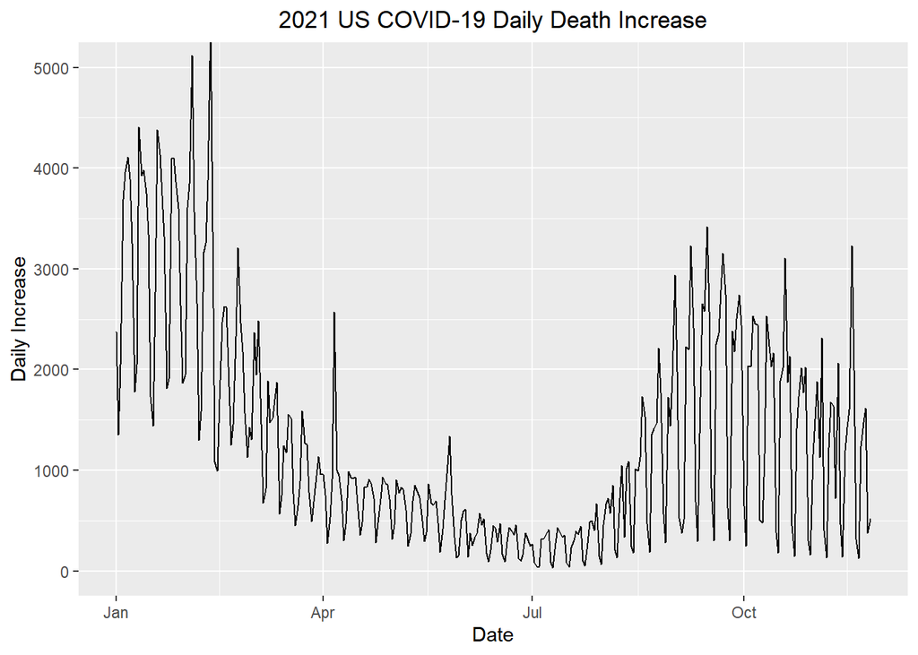

```r
US_2021_Death = na.omit(US_2021_Death)
US_2021_Death$Date = as.Date(US_2021_Death$Date)
ggplot()+geom_line(aes(Date,Death,group = 1),data = US_2021_Death)+
  coord_cartesian(ylim=c(0,5000)) + ylab("Daily Increase") + ggtitle("2021 US COVID-19 Daily Death Increase")+ theme(plot.title = element_text(hjust = 0.5))
```

###MDT

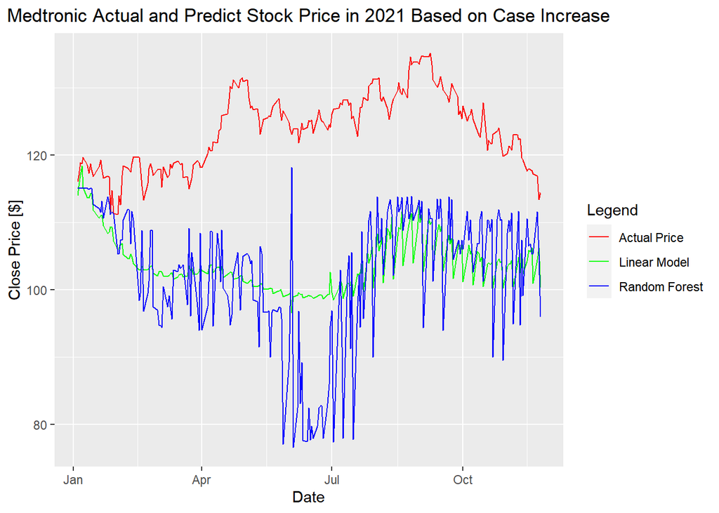

```r
#Linear
MDT_2021_case_pred = predict(MDT_model_A, newdata = MDT_2021_case)
MDT_2021_case$LPredict = 0
for(i in 1:nrow(MDT_2021_case)){
  MDT_2021_case$LPredict[i] = MDT_2021_case_pred[i]
}

MDT_2021_death_pred = predict(MDT_model_B, newdata = MDT_2021_death)
MDT_2021_death$LPredict = 0
for(i in 1:nrow(MDT_2021_death)){
  MDT_2021_death$LPredict[i] = MDT_2021_death_pred[i]
}
#RF
MDT_2021_case_rf = predict(MDT_cforest, newdata = MDT_2021_case)
MDT_2021_case$RfPredict = 0
for(i in 1:nrow(MDT_2021_case)){
  MDT_2021_case$RfPredict[i] = MDT_2021_case_rf[i]
}

MDT_2021_death_rf = predict(MDT_dforest, newdata = MDT_2021_death)
MDT_2021_death$RfPredict = 0
for(i in 1:nrow(MDT_2021_death)){
  MDT_2021_death$RfPredict[i] = MDT_2021_death_rf[i]
}
MDT_2021_case$Date = as.Date(MDT_2021_case$Date)
MDT_2021_case = na.omit(MDT_2021_case)
MDT_2021_death$Date = as.Date(MDT_2021_death$Date)
MDT_2021_death = na.omit(MDT_2021_death)
colors <- c("Actual Price" = "red", "Linear Model" = "green", "Random Forest" = "blue")

ggplot()+
   geom_line(aes(Date,Close,group=1, color ="Actual Price"),data=MDT_2021_case )+geom_line(aes(Date,LPredict,group=1, color = "Linear Model"),data=MDT_2021_case)+geom_line(aes(Date,RfPredict,group=1, color =  "Random Forest"),data=MDT_2021_case)+ggtitle("Medtronic Actual and Predict Stock Price in 2021 Based on Case Increase") + theme(plot.title = element_text(hjust = 0.5)) + labs(x = "Date", y = "Close Price [$]",color = "Legend") + scale_color_manual(values = colors)
```

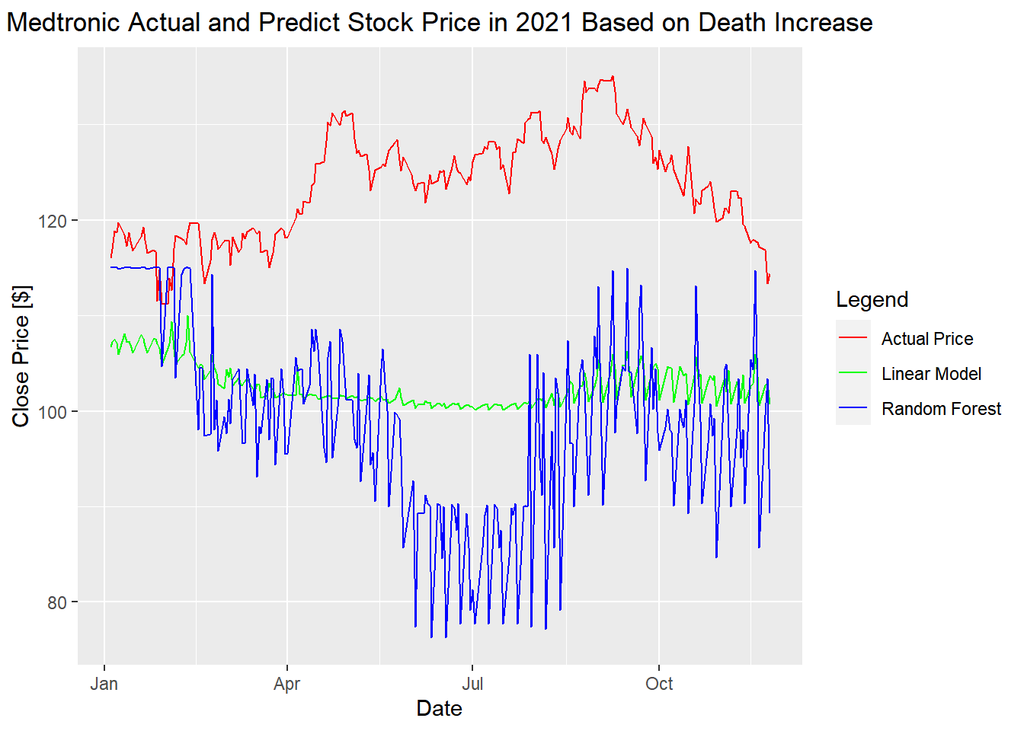

```r
ggplot()+
   geom_line(aes(Date,Close,group=1, color ="Actual Price"),data=MDT_2021_death )+geom_line(aes(Date,LPredict,group=1, color = "Linear Model"),data=MDT_2021_death)+geom_line(aes(Date,RfPredict,group=1, color =  "Random Forest"),data=MDT_2021_death)+
  ggtitle("Medtronic Actual and Predict Stock Price in 2021 Based on Death Increase") + theme(plot.title = element_text(hjust = 0.5)) + labs(x = "Date", y = "Close Price [$]",color = "Legend") + scale_color_manual(values = colors)
```

From the above plots, it is interesting to see that the predicted stock price for medtronic using Random Forest almost corresponding with the distribution of the cases and death change in 2021, which indicate a relatively low RMSE value. The prediction using the linear model for the cases and death change are relatively stable under the price range of $100 to $110. However, the actual stock price is changing in a direction that is directly opposite with the case and death rate change, in this case also oppsite to the prediction using Random Forest.

###SYK

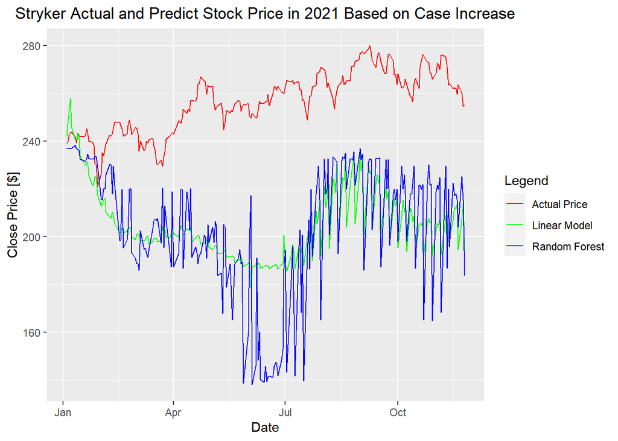

```r
#Linear
SYK_2021_case_pred = predict(SYK_model_A, newdata = SYK_2021_case)
SYK_2021_case$LPredict = 0
for(i in 1:nrow(SYK_2021_case)){
  SYK_2021_case$LPredict[i] = SYK_2021_case_pred[i]
}

SYK_2021_death_pred = predict(SYK_model_B, newdata = SYK_2021_death)
SYK_2021_death$LPredict = 0
for(i in 1:nrow(SYK_2021_death)){
  SYK_2021_death$LPredict[i] = SYK_2021_death_pred[i]
}
#RF
SYK_2021_case_rf = predict(SYK_cforest, newdata = SYK_2021_case)
SYK_2021_case$RfPredict = 0
for(i in 1:nrow(MDT_2021_case)){
  SYK_2021_case$RfPredict[i] = SYK_2021_case_rf[i]
}

SYK_2021_death_rf = predict(SYK_dforest, newdata = SYK_2021_death)
SYK_2021_death$RfPredict = 0
for(i in 1:nrow(SYK_2021_death)){
  SYK_2021_death$RfPredict[i] = SYK_2021_death_rf[i]
}

SYK_2021_case$Date = as.Date(SYK_2021_case$Date)
SYK_2021_case = na.omit(SYK_2021_case)
SYK_2021_death$Date = as.Date(SYK_2021_death$Date)
SYK_2021_death = na.omit(SYK_2021_death)
colors <- c("Actual Price" = "red", "Linear Model" = "green", "Random Forest" = "blue")

ggplot()+
   geom_line(aes(Date,Close,group=1, color ="Actual Price"),data=SYK_2021_case )+geom_line(aes(Date,LPredict,group=1, color = "Linear Model"),data=SYK_2021_case)+geom_line(aes(Date,RfPredict,group=1, color =  "Random Forest"),data=SYK_2021_case)+ggtitle("Stryker Actual and Predict Stock Price in 2021 Based on Case Increase") + theme(plot.title = element_text(hjust = 0.5)) + labs(x = "Date", y = "Close Price [$]",color = "Legend") + scale_color_manual(values = colors)
```

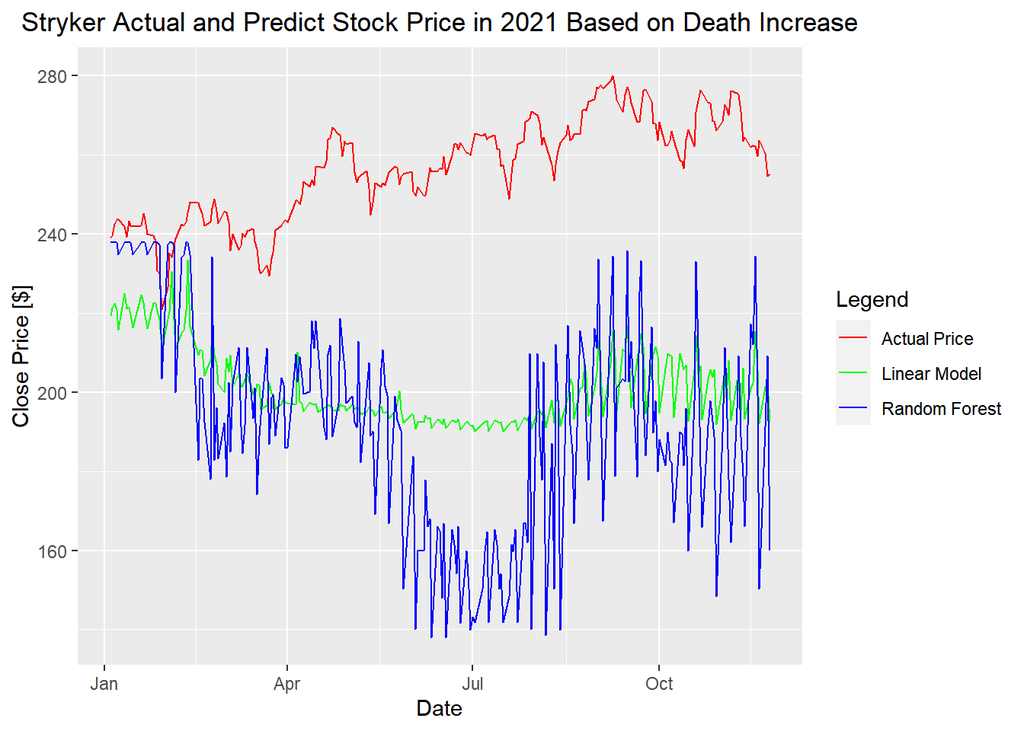

```r
ggplot()+
   geom_line(aes(Date,Close,group=1, color ="Actual Price"),data=SYK_2021_death )+geom_line(aes(Date,LPredict,group=1, color = "Linear Model"),data=SYK_2021_death)+geom_line(aes(Date,RfPredict,group=1, color =  "Random Forest"),data=SYK_2021_death)+
  ggtitle("Stryker Actual and Predict Stock Price in 2021 Based on Death Increase") + theme(plot.title = element_text(hjust = 0.5)) + labs(x = "Date", y = "Close Price [$]",color = "Legend") + scale_color_manual(values = colors)
```